# Pay Gaps between Asians and Whites Across High-Paying Industries

STATW4249, Spring 2016, Cycle 1-6: Tara Shui, YiBo Zhu, Haoyang Chen, Yi Zhou, Xinghao Gu

February 1, 2016

# 1 Introduction

In an article written by USA Today in October, 2014, [High Tech Pay Gap](http://www.usatoday.com/story/tech/2014/10/09/high-tech-pay-gap-hispanics-asians-african-americans/16606121/), research suggested that Asians in the high-tech industry had lower salaries than their white counterparts. This was an interesting statement, seeing as we often believe Asians make more than whites, particularly in high-paying industries such as tech. Using the American Community Survey (ACS) data from 2013, we decided to see if the survey data fit the findings from this article, and if there were similar differences in salary within other high-paying industries. We then took a closer comparative look at three particularly interesting industries–high-tech, finance, and medical–to see if the differences may be due to education.

## 1.1 Setting up the Bench

Libraries we need along the way:

```r
library(data.table)
library(dplyr)
library(plyr)
library(tidyr)
library(ggplot2)
library(RColorBrewer)
library(maps)
library(rCharts)
library(plotly)
library(gridExtra)
library(scales)
```

## 1.2 Reading the Data

Note: We chose to use OCCP (Occupation) instead of INDP (Industry). The census defines industry as the type of activity at a person’s place of work, and occupation as the kind of work a person does to earn a living. Therefore to get a more accurate sample of those in “high-tech”, we will be taking those who fall under “Computer and Mathematical Occupations” (CMM), since high-tech companies can stretch across many if not all industries.  
We also chose to use PERNP (Earnings) instead of PINCP (Income) to represent salary without annuities, dividends from stock, etc.

The following list shows the variables we extracted:  
RAC1P - Recoded detailed race code  
PERNP - Total person’s earnings  
OCCP - Occupation recode for 2012 and later  
PWGTP - (Replicate weights)  
SCHL - Educational attainment  
ST - State Code

```r
cols <- c('RAC1P', 'PERNP', 'OCCP', 'PWGTP', 'SCHL', 'ST')
pusa <- fread('ss13pusa.csv', select = cols)
```

```
##
Read 0.0% of 1613672 rows
Read 14.9% of 1613672 rows
Read 29.1% of 1613672 rows
Read 43.4% of 1613672 rows
Read 57.6% of 1613672 rows
Read 71.9% of 1613672 rows
Read 86.1% of 1613672 rows
Read 99.8% of 1613672 rows
Read 1613672 rows and 6 (of 283) columns from 1.416 GB file in 00:00:11
```

```r
pusb <- fread('ss13pusb.csv', select = cols)
```

```
##
Read 0.0% of 1519123 rows
Read 15.1% of 1519123 rows
Read 30.3% of 1519123 rows
Read 45.4% of 1519123 rows
Read 59.9% of 1519123 rows
Read 75.0% of 1519123 rows
Read 89.5% of 1519123 rows
Read 1519123 rows and 6 (of 283) columns from 1.333 GB file in 00:00:10
```

```r
pus <- bind_rows(pusa, pusb)
rm(pusa, pusb)
str(pus)
```

```
## Classes 'tbl_df', 'tbl' and 'data.frame':    3132795 obs. of  6 variables:
##  $ ST   : int  1 1 1 1 1 1 1 1 1 1 ...
##  $ PWGTP: int  65 51 62 232 97 449 16 30 7 52 ...
##  $ SCHL : int  19 20 16 19 19 21 14 16 9 1 ...
##  $ OCCP : int  NA 4700 7240 NA NA 2310 NA 6260 NA 8740 ...
##  $ PERNP: int  0 52000 99000 0 0 39000 0 1100 NA 0 ...
##  $ RAC1P: int  1 2 2 2 2 2 3 3 3 2 ...
```

## 1.3 Data Manipulation

The following list shows the eight highest-paying salaries on average by occupation:  
MGR - Management, Business, Science, and Arts Occupations  
CMM - Computer and Mathematical Occupations  
FIN - Financial Specialists  
LGL - Legal Occupations  
MED - Healthcare Practitioners and Technical Occupations  
BUS - Business Operations Specialists  
ENG - Architecture and Engineering Occupations  
SCI - Life, Physical, and Social Science Occupations

```r
# Remove rows with NA in pus
pus <- pus[complete.cases(pus),]

# Add state names and abbreviations
ST.anno = read.csv('statenames.csv', header = T)
pus <- mutate(pus, STname = ST.anno[ST, 2], STabbr = ST.anno[ST, 3])

# Extract the Asians and Whites data
pus <- filter(pus, RAC1P == 1 | RAC1P == 6)
pus$RAC1P <- as.factor(pus$RAC1P)
levels(pus$RAC1P) <- c('White', 'Asian')

# Recode OCCP and choose eight OCCP with highest salary or significance differences
pus$OCCP <- ifelse(pus$OCCP >= 10 & pus$OCCP <= 430, 1, pus$OCCP)
pus$OCCP <- ifelse(pus$OCCP >= 1005 & pus$OCCP <= 1240, 2, pus$OCCP)
pus$OCCP <- ifelse(pus$OCCP >= 800 & pus$OCCP <= 950, 3, pus$OCCP)
pus$OCCP <- ifelse(pus$OCCP >= 2105 & pus$OCCP <= 2160, 4, pus$OCCP)
pus$OCCP <- ifelse(pus$OCCP >= 3000 & pus$OCCP <= 3540, 5, pus$OCCP)
pus$OCCP <- ifelse(pus$OCCP >= 510 & pus$OCCP <= 740, 6, pus$OCCP)
pus$OCCP <- ifelse(pus$OCCP >= 1300 & pus$OCCP <= 1560, 7, pus$OCCP)
pus$OCCP <- ifelse(pus$OCCP >= 1600 & pus$OCCP <= 1965, 8, pus$OCCP)

pus <- filter(pus, OCCP %in% c(1:8))
pus$OCCP <- as.factor(pus$OCCP)

levels(pus$OCCP) <- c('MGR', 'CMM', 'FIN', 'LGL', 'MED' , 'BUS', 'ENG', 'SCI')

# Extract BS, MS, Phd data
pus <- filter(pus, SCHL %in% c(21, 22, 24))
pus$SCHL <- as.factor(pus$SCHL)
levels(pus$SCHL) <- c('Bachelor', 'Master', 'Doctorate')
str(pus)
```

```
## Classes 'tbl_df', 'tbl' and 'data.frame':    222838 obs. of  8 variables:
##  $ ST    : int  1 1 1 1 1 1 1 1 1 1 ...
##  $ PWGTP : int  171 7 65 251 246 394 475 18 90 80 ...
##  $ SCHL  : Factor w/ 3 levels "Bachelor","Master",..: 1 1 2 1 1 2 1 2 1 1 ...
##  $ OCCP  : Factor w/ 8 levels "MGR","CMM","FIN",..: 2 5 5 1 1 1 1 1 1 1 ...
##  $ PERNP : int  130000 30300 50000 60000 42200 100000 12000 0 30000 11200 ...
##  $ RAC1P : Factor w/ 2 levels "White","Asian": 2 1 1 1 1 1 1 1 1 1 ...
##  $ STname: Factor w/ 52 levels "Alabama","Alaska",..: 1 1 1 1 1 1 1 1 1 1 ...
##  $ STabbr: Factor w/ 52 levels "AK         ",..: 2 2 2 2 2 2 2 2 2 2 ...
```

# 2 Big Picture: Comparing Asians’ and whites’ salaries by different occupations

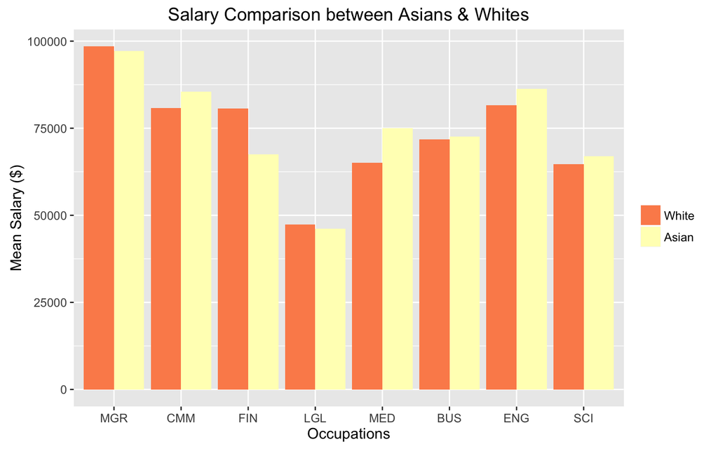

```r
pus_race_occp <- ddply(pus, .(RAC1P, OCCP), summarise, MEAN = weighted.mean(PERNP, PWGTP, na.rm = T))
ggplot(pus_race_occp, aes(x=OCCP, y=MEAN, fill=factor(RAC1P))) +
  geom_bar(stat="identity",position="dodge") +
  scale_fill_brewer(palette="RdYlGn") +
  labs(fill="") +
  ylab("Mean Salary ($)") +
  xlab("Occupations") +
  ggtitle(paste("Salary Comparison between Asians & Whites")) +
  theme(axis.text.x = element_text(angle = 30, hjust = 1),
        panel.background = element_rect(fill = 'white' )) +
  theme_grey(base_size = 12)
```

# 3 Closer look: High-Tech (CMM)

Let’s take a look at those who work in tech.

## 3.1 Educational Distribution (High-Tech)

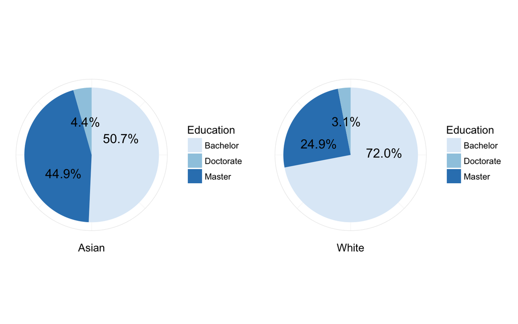

```r
# Specify CMM occupation
CMM <- filter(pus, OCCP == 'CMM')
# Calculate the freq of diff degrees
CMM_Edu <- ddply(CMM, .(RAC1P, SCHL), summarise, Total = length(SCHL))

# Pie Charts for CMM Levels of Education
Asian <- filter(CMM_Edu, RAC1P == 'Asian')
asianDegreePerc <- Asian$Total/sum(Asian$Total)
Asian<- cbind(Asian, asianDegreePerc)
Education <- levels(Asian$SCHL)
White <- filter(CMM_Edu, RAC1P == "White")
whiteDegreePerc <- White$Total/sum(White$Total)
White<- cbind(White, whiteDegreePerc)

asian_plot <- ggplot(Asian, aes(x="", y=asianDegreePerc, fill=Education)) +
  geom_bar(width = 1, stat = "identity") +
  coord_polar("y", start=0) +
  scale_fill_brewer(palette="Blues") +
  theme_minimal() +
  theme(axis.text.x=element_blank()) +
  geom_text(aes(y = asianDegreePerc/3 + c(0, cumsum(asianDegreePerc)[-length(asianDegreePerc)]),
                label = percent(asianDegreePerc)), size=5) +
  labs(x = NULL ,y = "Asian")

white_plot <- ggplot(White, aes(x="", y=whiteDegreePerc, fill=Education)) +
  geom_bar(width = 1, stat = "identity") +
  coord_polar("y", start=0) +
  scale_fill_brewer(palette="Blues") +
  theme_minimal() +
  theme(axis.text.x=element_blank()) +
  geom_text(aes(y = whiteDegreePerc/3 + c(0, cumsum(whiteDegreePerc)[-length(whiteDegreePerc)]),
                label = percent(whiteDegreePerc)), size=5) +
  labs(x = NULL ,y = "White")

grid.arrange(asian_plot, white_plot, ncol=2)
```

Interestingly enough, within those who have occupations that fall under CMM, there is a higher proportion of Master’s degree holders amongst the Asian population than the white population. This may give an explanation for the higher average salary.

## 3.2 Salary Contrast by State (High-Tech)

To get a feel for which states have higher pay for whites and which have higher pay for Asians in the tech industry, we took the difference in salary and created the following state map. The darker blue a state is, the more Asians make in that state on average. The lighter a state is, the more whites make compared to their Asian counterparts. Interactively scroll over each state on the map to get state-specific numbers.

```r
CMM_Asian <- filter(CMM, RAC1P == 'Asian')
CMM_White <- filter(CMM, RAC1P == 'White')
CMM_state_asian <- ddply(CMM_Asian, .(STname), summarise, Asian = weighted.mean(PERNP, PWGTP))
CMM_state_white <- ddply(CMM_White, .(STname), summarise, White = weighted.mean(PERNP, PWGTP))
CMM_state_asian <- filter(CMM_state_asian, STname != 'NA')
CMM_state_white <- filter(CMM_state_white, STname != 'NA')
state_name <- fread('statenames.csv', select = c('name', 'abbr'))
CMM_state_salary <-merge(state_name, CMM_state_asian, by.x = 'name', by.y = 'STname', all.x = TRUE)
CMM_state_salary <-merge(CMM_state_salary, CMM_state_white, by.x = 'name', by.y = 'STname', all.x = TRUE)

# Calculate difference between mean salaries
CMM_state_salary$diff <- apply(CMM_state_salary, 1, function(x) {as.numeric(x[3]) - as.numeric(x[4])})
CMM_state_salary[is.na(CMM_state_salary$diff),]$diff <- 0

CMM_state_salary$hover <- with(CMM_state_salary, paste(name, '<br>', "Difference", diff ))
# Give state boundaries a white border
l <- list(color = toRGB("white"), width = 2)
# Specify some map projection/options
g <- list(
    scope = 'usa',
    projection = list(type = 'albers usa'),
    showlakes = TRUE,
    lakecolor = toRGB('white')
)

plot_ly(CMM_state_salary, z = diff, text = hover, locations = abbr, type = 'choropleth',
        locationmode = 'USA-states', color = diff, colors = 'Blues',
        marker = list(line = l), colorbar = list(title = "USD")) %>%
    layout(title = 'Difference in Salary by State － CMM', geo = g)
```

[interactive chart not shown]

We saw that as a whole, Asians make more on average than their white counterparts in the tech industry. However, we can see from the state map that there are a few states in which whites make significantly more than Asians (North Dakota, Indiana, Rhode Island). Yet this difference in a few states does not offset the overall difference we saw in the previous graph.

Note: none of the differences we see on these maps are due to lack of data (i.e. NULL fields where no Asians or no whites are in an industry). If there was a race with a NULL field, we set the difference to 0.

# 4 Closer Look: Finance (FIN)

Let’s take a look at those who work in the financial sector.

## 4.1 Educational Distribution (Finance)

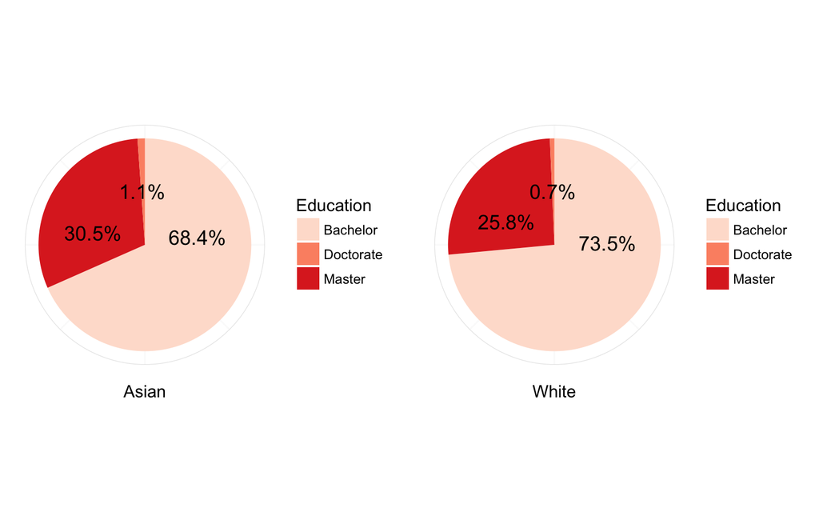

```r
# Specify FIN occupation
FIN <- filter(pus, OCCP == 'FIN')
FIN_Edu <- ddply(FIN, .(RAC1P, SCHL), summarise, Total = length(SCHL))

# Pie Chart for FIN levels of education
Asian <- filter(FIN_Edu, RAC1P == 'Asian')
asianDegreePerc <- Asian$Total/sum(Asian$Total)
Asian<- cbind(Asian, asianDegreePerc)
Education <- levels(Asian$SCHL)
White <- filter(FIN_Edu, RAC1P == "White")
whiteDegreePerc <- White$Total/sum(White$Total)
White<- cbind(White, whiteDegreePerc)

asian_plot <- ggplot(Asian, aes(x="", y=asianDegreePerc, fill=Education)) +
  geom_bar(width = 1, stat = "identity") +
  coord_polar("y", start=0) +
  scale_fill_brewer(palette="Reds") +
  theme_minimal() +
  theme(axis.text.x=element_blank()) +
  geom_text(aes(y = asianDegreePerc/3 + c(0, cumsum(asianDegreePerc)[-length(asianDegreePerc)]),
                label = percent(asianDegreePerc)), size=5) +
  labs(x = NULL ,y = "Asian")

white_plot <- ggplot(White, aes(x="", y=whiteDegreePerc, fill=Education)) +
  geom_bar(width = 1, stat = "identity") +
  coord_polar("y", start=0) +
  scale_fill_brewer(palette="Reds") +
  theme_minimal() +
  theme(axis.text.x=element_blank()) +
  geom_text(aes(y = whiteDegreePerc/3 + c(0, cumsum(whiteDegreePerc)[-length(whiteDegreePerc)]),
                label = percent(whiteDegreePerc)), size=5) +
  labs(x = NULL ,y = "White")

grid.arrange(asian_plot, white_plot, ncol=2)
```

This is interesting. We see that these findings conflict with what we observed about the CMM/tech occupations. Although there is still a higher proportion of Master’s degree holders amongst the Asians in FIN, they have, on average, a lower salary than their white counterparts. Although the differences are not significant, it is interesting to see that many white individuals in FIN only hold Bachelor’s degrees.

## 4.2 Salary Contrast by State (Finance)

```r
FIN_Asian <- filter(FIN, RAC1P == 'Asian')
FIN_White <- filter(FIN, RAC1P == 'White')
FIN_state_asian <- ddply(FIN_Asian, .(STname), summarise, Asian = weighted.mean(PERNP, PWGTP))
FIN_state_white <- ddply(FIN_White, .(STname), summarise, White = weighted.mean(PERNP, PWGTP))
FIN_state_asian <- filter(FIN_state_asian, STname != 'NA')
FIN_state_white <- filter(FIN_state_white, STname != 'NA')
FIN_state_salary <-merge(state_name, FIN_state_asian, by.x = 'name', by.y = 'STname', all.x = TRUE)
FIN_state_salary <-merge(FIN_state_salary, CMM_state_white, by.x = 'name', by.y = 'STname', all.x = TRUE)

# Calculate difference between mean salaries
FIN_state_salary$diff <- apply(FIN_state_salary, 1, function(x) {as.numeric(x[3]) - as.numeric(x[4])})
FIN_state_salary[is.na(FIN_state_salary$diff),]$diff <- 0
FIN_state_salary[FIN_state_salary$abbr=='TX', ]$diff <- 0
FIN_state_salary$hover <- with(FIN_state_salary, paste(name, '<br>', "Difference", diff ))
# give state boundaries a white border
l <- list(color = toRGB("white"), width = 2)
# specify some map projection/options
g <- list(
    scope = 'usa',
    projection = list(type = 'albers usa'),
    showlakes = TRUE,
    lakecolor = toRGB('white')
)

plot_ly(FIN_state_salary, z = diff, text = hover, locations = abbr, type = 'choropleth',
        locationmode = 'USA-states', color = diff, colors = 'Reds',
        marker = list(line = l), colorbar = list(title = "USD")) %>%
    layout(title = 'Difference in Salary by State － FIN', geo = g)
```

[interactive chart not shown]

The state-by-state comparisons within the FIN occupations largely align with our overall findings. Georgia is an exception, with Asians making on average $51275.41 more. Otherwise, whites in FIN making more than their Asian counterparts applies to most individual states.

# 5 Closer look: Medical (MED)

Finally, let’s take a look at those who work in a medical-related practice.

## 5.1 Educational Distribution (Medical)

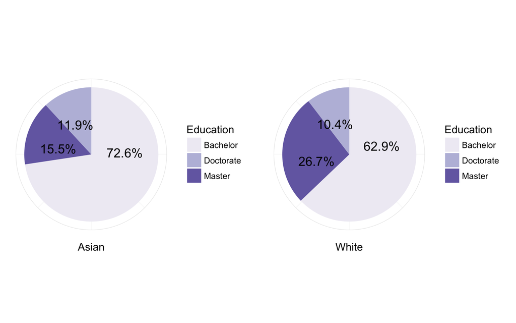

```r
# Specify MED occupation
MED <- filter(pus, OCCP == 'MED')
MED_Edu <- ddply(MED, .(RAC1P, SCHL), summarise, Total = length(SCHL))

# Pie Chart for MED levels of education
Asian <- filter(MED_Edu, RAC1P == 'Asian')
asianDegreePerc <- Asian$Total/sum(Asian$Total)
Asian<- cbind(Asian, asianDegreePerc)
Education <- levels(Asian$SCHL)
White <- filter(MED_Edu, RAC1P == "White")
whiteDegreePerc <- White$Total/sum(White$Total)
White<- cbind(White, whiteDegreePerc)

asian_plot <- ggplot(Asian, aes(x="", y=asianDegreePerc, fill=Education)) +
  geom_bar(width = 1, stat = "identity") +
  coord_polar("y", start=0) +
  scale_fill_brewer(palette="Purples") +
  theme_minimal() +
  theme(axis.text.x=element_blank()) +
  geom_text(aes(y = asianDegreePerc/3 + c(0, cumsum(asianDegreePerc)[-length(asianDegreePerc)]),
                label = percent(asianDegreePerc)), size=5) +
  labs(x = NULL ,y = "Asian")

white_plot <- ggplot(White, aes(x="", y=whiteDegreePerc, fill=Education)) +
  geom_bar(width = 1, stat = "identity") +
  coord_polar("y", start=0) +
  scale_fill_brewer(palette="Purples") +
  theme_minimal() +
  theme(axis.text.x=element_blank()) +
  geom_text(aes(y = whiteDegreePerc/3 + c(0, cumsum(whiteDegreePerc)[-length(whiteDegreePerc)]),
                label = percent(whiteDegreePerc)), size=5) +
  labs(x = NULL ,y = "White")

grid.arrange(asian_plot, white_plot, ncol=2)
```

The findings on these graphs are interesting. We know that MED had a large overall difference in salaries between Asians and whites, yet there is a significantly larger proportion of Master’s degree holders within the white MED demographic. This may be due to the fact that medical degrees themselves do not count towards a higher level of education. Those that hold Doctorate’s or Master’s degrees most likely received degrees that do not contribute directly to their positions as doctors, surgeons, etc. That may explain why the differences in degrees holders here do not correlate with our overall findings.

## 5.2 Salary Contrast by State (Medical)

Let’s also compare average salaries in MED by state just as we did before. The darker purple a state is, the more Asians make in that state on average. The lighter a state is, the more whites make compared to their Asian counterparts.

```r
MED_Asian <- filter(MED, RAC1P == 'Asian')
MED_White <- filter(MED, RAC1P == 'White')
MED_state_asian <- ddply(MED_Asian, .(STname), summarise, Asian = weighted.mean(PERNP, PWGTP))
MED_state_white <- ddply(MED_White, .(STname), summarise, White = weighted.mean(PERNP, PWGTP))
MED_state_asian <- filter(MED_state_asian, STname != 'NA')
MED_state_white <- filter(MED_state_white, STname != 'NA')
MED_state_salary <-merge(state_name, MED_state_asian, by.x = 'name', by.y = 'STname', all.x = TRUE)
MED_state_salary <-merge(MED_state_salary, MED_state_white, by.x = 'name', by.y = 'STname', all.x = TRUE)

# Calculate difference between mean salaries
MED_state_salary$diff <- apply(MED_state_salary, 1, function(x) {as.numeric(x[3]) - as.numeric(x[4])})
MED_state_salary[is.na(MED_state_salary$diff),]$diff <- 0

MED_state_salary$hover <- with(MED_state_salary, paste(name, '<br>', "Difference", diff ))
# give state boundaries a white border
l <- list(color = toRGB("white"), width = 2)
# specify some map projection/options
g <- list(
    scope = 'usa',
    projection = list(type = 'albers usa'),
    showlakes = TRUE,
    lakecolor = toRGB('white')
)

plot_ly(MED_state_salary, z = diff, text = hover, locations = abbr, type = 'choropleth',
        locationmode = 'USA-states', color = diff, colors = 'Purples',
        marker = list(line = l), colorbar = list(title = "USD")) %>%
    layout(title = 'Difference in Salary by State － MED', geo = g)
```

[interactive chart not shown]

As expected, we see that there are many states in which Asians in MED make significantly more than their white counterparts - up to 60K. On the other side of the spectrum, there are a few states in which whites make at most 20K more than Asians.

# 6 Conclusion

We were inspired to look into this topic after seeing the USA Today article, which suggested that whites working in the high-tech industry earned more than their Asian counterparts. However, our findings conflicted with theirs. We found that in almost all of the highest paying occupational fields, Asians tended to make marginally more than whites with few exceptions (FIN). We looked towards levels of education to see if that may explain the difference, but found conflicting results. In tech, Asians had higher salary on average and indeed had a higher proportion of Master’s degrees holders. However, in finance, Asians had lower salary on average yet still had a marginally higher proportion of Master’s degrees holders. In all fields, differences in proportion of Doctorate’s degree holders were insignificant. Finally, we were surprised to see that amongst MED occupations, whites actually had a higher proportion of Master’s degrees holders, yet made much less on average than their Asian counterparts. We conclude that level of education does not necessarily indicate higher pay on average. Overall, most individual states aligned with our overall findings between Asian and white salaries. However, certain exceptions may suggest indication as to which state you might like to go to receive a more competitive pay. Hope you enjoyed our presentation!